# **Class 11: Terrorism and Weapons of Mass Destruction**<sup>1</sup>

**EXERCISE 33. In 1970, approximately what percentage of the incidents involved explosives? Firearms**?  
**Around 52% of the incidents involved explosives and around 12% of the incidents involved firearms in 1970.**

**EXERCISE 34. In 1980 was the percentage of unknown/other incidents greater or less than the percentage of incendiary incidents**?**  
**The percentage of unknown/other incidents was greater than the percentage of incendiary incidents in 1980.**

**EXERCISE 35. Which two weapon types are used most frequently in terrorist attacks**?  
**Explosives and firearms are the most used weapons in terrorist attacks.**

**EXERCISE 36. Was the use of CBRN weapons usually less than 1% of all incidents**?  
**Yes, the use of CBRN weapons was usually less than 1% of all incidents.**

**EXERCISE 37. Does this support the media image that terrorists regularly rely on sophisticated weapons**?  
**No, this doesn’t support the media image that terrorists regularly rely on sophisticated weapons.**

Next we will look at how many deaths were caused by CBRN weapons compared to other weapons. The steps are the same, but now use counts of `Fatalities` instead of `Incidents`.

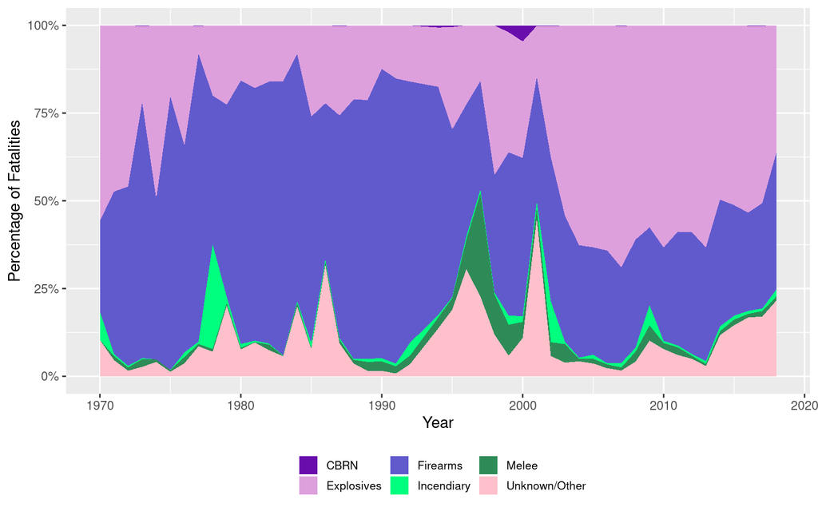

```r
# Sum the total number of deaths (Fatalities) for each year
GTDdeath = summarise( group_by(GTDdata, Year), TotalDeaths=sum(Fatalities, na.rm = TRUE))

# Sum the fatalities grouped by weapon type and year
GTDweaponDeath = summarise( group_by(GTDdata, Year, WeaponType),
                      Deaths=sum(Fatalities, na.rm = TRUE))

# Merge the two data sets and find percentage of deaths by weapon type.
GTDweaponDeath <- left_join(GTDweaponDeath, GTDdeath, by="Year")
GTDweaponDeath = mutate(GTDweaponDeath, PercentDeath = Deaths/TotalDeaths)

# Create a stacked-line graph
qplot(Year, PercentDeath, data=GTDweaponDeath, fill=WeaponType,
      geom="area") + ylab("Percentage of Fatalities") +
  scale_y_continuous(labels=percent) + scale_fill_manual(values=customColors) +
  theme(legend.title=element_blank(), legend.key.size = unit(.5, "cm"),
        legend.position="bottom", legend.text=element_text(size=8))
```

**EXERCISE 38. What new dataframe was created, and what information does it contain**?  
**GTDWeaponDeath dataframe was created, and it contains information about the sum and percentage of fatalities grouped by weapon type and year.**

**EXERCISE 40. In the stacked-line graph, can you see a small spike in the percentage of CBRN fatalities? In what year**? (*If you can’t see the spike, or can’t tell what year, you may want to facet the graph by weapon*.)  
**Yes, there is a small spike in the year 2000.**

**EXERCISE 41. The CBRN “spike” accounts for approximately what percent of the terrorism-related fatalities in that year**?  
**The spike accounts for approximately 5% of the terrorism related fatalities in the year 2000.**

**EXERCISE 42. Can you identify which event we found earlier that might have caused this spike**?(Hint: Look back at Exercise 19.)  
**It must have been the incident with 200 deaths in Uganda in 2000.**

While 200 deaths are hardly insignificant, it is still only a small percentage of all fatalities. Other weapons currently cause a much larger loss of life.

**EXERCISE 43. Repeat the process with non-fatal injuries, (`Wounded`), and describe any patterns that you find related to CBRN injuries**.

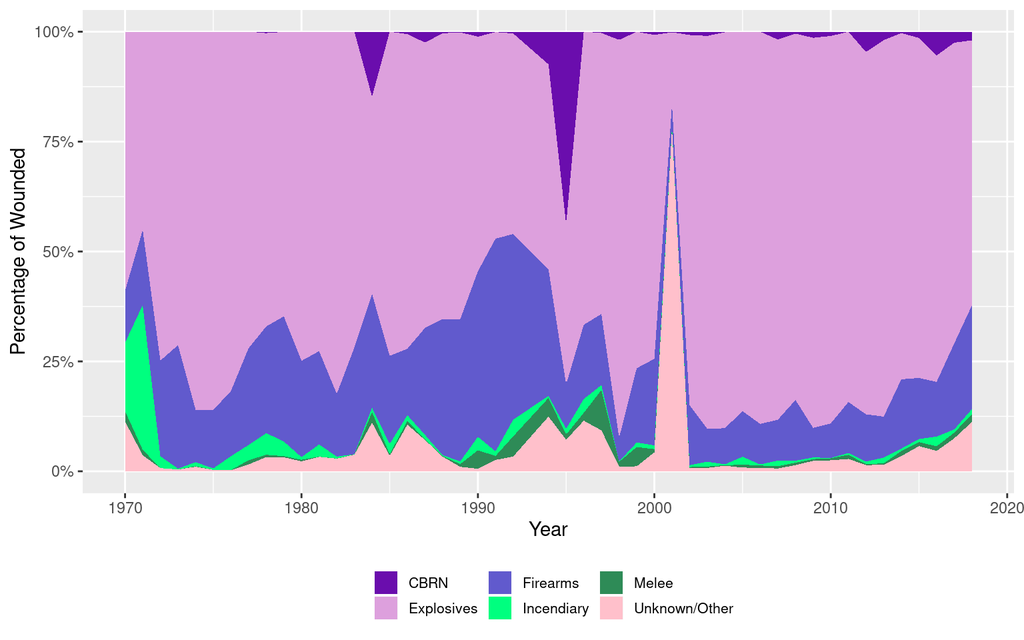

```r
GTDwounded = summarise( group_by(GTDdata, Year), TotalWounded=sum(Wounded, na.rm = TRUE))

GTDweaponWounded = summarise( group_by(GTDdata, Year, WeaponType),
                      Wounded=sum(Wounded, na.rm = TRUE))

GTDweaponWounded <- left_join(GTDweaponWounded, GTDwounded, by="Year")

GTDweaponWounded = mutate(GTDweaponWounded, PercentWounded = Wounded/TotalWounded)
qplot(Year, PercentWounded, data=GTDweaponWounded, fill=WeaponType,
      geom="area") + ylab("Percentage of Wounded") +
  scale_y_continuous(labels=percent) + scale_fill_manual(values=customColors) +
  theme(legend.title=element_blank(), legend.key.size = unit(.5, "cm"),
        legend.position="bottom", legend.text=element_text(size=8))
```

**There are more spikes related to the CBRN injuries in wounded than in deaths. The largest spike is around 1995 when approximately 40% of the injuries were caused by CBRN weapons.**

## **Drawing Conclusions from our Graphs**

These graphs and the GTD website allowed us to analyze CBRN attacks. We see that they typically resulted in a relatively small number of deaths and injuries, but occasionally produced a considerable number of deaths $(200)$ or injuries (~$5500)$. However, these numbers are far from the millions threatened.

It is worth noting that the most harmful CBRN attacks used chemical weapons (with one exception),<sup>3</sup> informing us that most attacks with biological, radiological, or nuclear weapons were either not attempted, or were not successful. In *Putting Terrorism in Context*, LaFree, Dugan, & Miller confirm that few organizations are willing to adopt biological or chemical weapons (2015, p. 189), and that there were only 13 out of 113,000 recorded cases of radiological weapons at that time. There are also no cases of nuclear weapons, in part due to the difficulty of obtaining and weaponizing the materials involved (2015, p. 191).

Using the stacked-graph plot, we were able to see that in terms of incidents, fatalities, and injuries, CBRN weapons are relatively rare compared to firearms and explosives. However, we saw that the attack by Aum Shinrikyo was damaging enough to result in over 1/3 of all the injuries in the year it took place, suggesting that CBRN weapons do have the potential to do significant damage. NATO’s webpage “Weapons of Mass Destruction” reinforces that the use of CBRN weapons could produce “incalculable consequences for global stability and prosperity” (2015).

It is important to correct the image that terrorists routinely use sophisticated weapons. Resources are primarily needed to stop terrorism using common weapons (explosives and firearms), which are currently causing the most deaths and injuries. However, given their high potential for damage, we can conclude that it is well worth taking preventative counterterrorism measures against future CBRN attacks.

Since there have been just a few CBRN attacks, it does mean that the first major attack will be difficult to predict. One potential avenue for indirectly anticipating major attacks is looking at what causes terrorist organizations to escalate the caliber of weapons they use. For example, terrorist organizations on the brink of defeat or with doomsday beliefs may be more inclined to use superweapons (Laqueur, 1996). Another avenue is performing case studies on the few organizations which made attempts, similar to the case studies in the Global Terrorism Index report (Institute for Economics and Peace, 2014) on the most dangerous terrorist organizations in 2014. It may be advisable to investigate each type of weapon separately, since patterns of attack with chemical weapons are unlikely to resemble biological weapons which are unlikely to resemble radiological or nuclear weapons. Another sophisticated and highly dangerous weapon raised by Laqueur (1996) is cyber-terrorism, which could cause as much damage as CBRN weapons without the difficulty in procuring and processing materials. Unfortunately, data on cyber-terrorism is not currently available in the GTD.

**EXERCISE 44. Develop your own question of interest in relation to these data and create a graph to address your question. Do you see any interesting patterns if you use different colors, filters, or facets for particular variables of interest?**  
You may also go to the Executive Summary of the Global Terrorism Index report (Institute for Economics and Peace, 2014) (http://www.visionofhumanity.org/sites/default/files/Global%20Terrorism%20Index%20Report%202014_0.pdf) and look for interesting claims that you can investigate. Submit at least one plot with a brief interpretation.

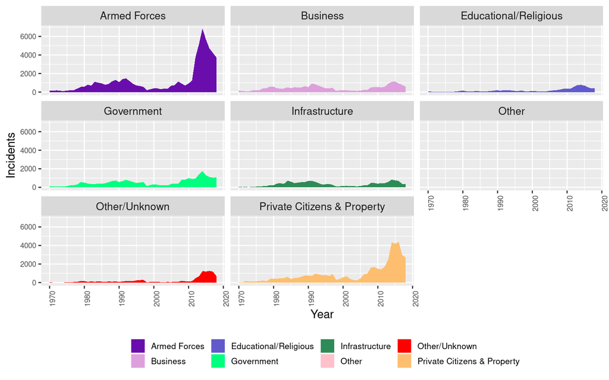

```r
GTDtarget = summarise( group_by(GTDdata, Year, TargetType), Incidents=n())


qplot(Year, Incidents, data=GTDtarget, fill=TargetType, geom="area")  + ylab("Incidents") +
  facet_wrap(~TargetType, ncol=3) + scale_fill_manual(values=customColors) +
  theme(legend.title=element_blank(), legend.key.size = unit(.5, "cm"),
        legend.position="bottom", strip.text=element_text(size=10),
        legend.text=element_text(size=8), axis.text=element_text(size=7),
        axis.text.x = element_text(angle = 90))
```

## **Homework**

1. Answer the 44 questions in this document in the space provided below each exercise.
2. **Change the name and date at the top of the file. Knit your file to an HTML document**.
3. **Open the HTML file in a browser, and save the file WITH YOUR NAME(s) in it**.

D. Then post the file in Moodle or email to me.

#### **Endnotes**

<sup>1</sup> This activity was created by Ying Long, Zachary Segall, and Shonda Kuiper. All rights reserved. Date: 7/25/2015

<sup>2</sup>For an incident to be categorized as a terrorist attack and included in this dataset, each incident must meet all three of these attributes: (1) The incident must be intentional, (2) The incident must entail some level of violence or immediate threat of violence and (3) The perpetrators of the incidents must be sub-national actors. In addition each incident must include at least two of the following three criteria 1) The act must be aimed at attaining a political, economic, religious, or social goal, (2) There must be evidence of an intention to coerce, intimidate, or convey some other message to a larger audience (or audiences) than the immediate victims and (3) The action must be outside the context of legitimate warfare activities (see the [GTD Codebook](http://www.start.umd.edu/gtd/downloads/Codebook.pdf) for more details). Data files from 1993 were lost by the company originally managing the database, so data from that year are missing.

<sup>3</sup>One key exception is the 1984 salmonella attack (classified as biological) by the Rajneeshee Cult in Oregon in an attempt to sway an election which injured several hundred people.

#### **Sources**

Kaszeta, D. (2014, July 29). It is Time to Retire ‘Weapons of Mass Destruction’. *Cicero Magazine* Retried from http://ciceromagazine.com/opinion/it-is-time-to-retire-weapons-of-mass-destruction/.

LaFree, G., Dugan, L., & Miller, E. (2015). *Putting terrorism in context: Lessons from the Global Terrorism Database*. New York, NY: Routledge.

Laqueur, W. (1996). Postmodern Terrorism. *Foreign Affairs, Vol. 75*(no. 5), pp. 24-37.

National Consortium for the Study of Terrorism and Responses to Terrorism (START). (2013). Global Terrorism Database [Data file]. Retrieved from http://www.start.umd.edu/gtd.

NATO. (2015). *Weapons of Mass Destruction*. Retrieved from http://www.nato.int/cps/en/natohq/topics_50325.htm.

Otterman, S. (2003, April 21). IRAQ: America’s Rationale for War. *Backgrounder* Retrieved from http://www.cfr.org/iraq/iraq-americas-rationale-war/p7693#p1.